# Using GRID3 Data

Alina Game

10 November 2019

This exercise provides an example of how we can use GRID3 data within an application.

> This code is available via GitHub at www.github/GRID3/data-example

# Exercise Overview

Using geospatial analysis in R, this demo will show an assessment of health facility coverage for maternal health using the GRID3 population data.

In this exercise we are going to:

1. Load some spatial data
2. Subset the data to focus on points of interest
3. Aggregate dataset using some basic geospatial techniques
4. Try and identify connections between datasets

# Loading Packages

For this demo, we will be using the **sp** package along with **raster** to provide most of our spatial functions. The **dismo** and **spatialEco** package provide additional functions which we will use for some of our spatial analysis.

# Loading Datasets

We have four datasets used in this example:

> These datasets can be obtained from the GRID3 Nigeria Data portal at https://grid3.gov.ng/
1. **Health facility locations**:
2. **Ward boundaries**
3. **Gridded population (women age 15-49) data for Kaduna State**
4. **State boundary**

```r
data <- read.csv("Data/kaduna_health_sub.csv")
r <- raster("Data/nga_pop_wocba.tif")
boundaries <- shapefile("Data/kaduna_wards.shp")
state<-shapefile("Data/kaduna_state.shp")
```

We will view our health facilty data below. In total there are 1671 health centres recorded within the dataset. This includes data such as their location, whether the type of health centre *(primary, secondary, tertiary)*, and whether it is private or publicly owned. An example of some of the data is shown below:

```r
head(data[8:18], n = 3)
```

```
##   latitude longitude ri_service            timestamp cce_availa
## 1 10.70722  6.688533    Unknown 2018-09-25T14:24:37Z    Unknown
## 2 10.72505  6.745297    Unknown 2018-09-25T14:34:39Z    Unknown
## 3 10.64830  7.041757    Unknown 2018-09-25T14:24:39Z    Unknown
##                category                            global_id
## 1 Primary Health Center 965e847e-a149-4edf-90d3-30c9461959fa
## 2 Primary Health Center 1938268f-426c-4221-a264-ee7bcfd6b2e0
## 3 Primary Health Clinic ad534918-f452-4f81-b313-61ee4cbcbf36
##                        name functional    type ownership
## 1 Pole Wire's Health Center    Unknown Primary    Public
## 2       Health Center Gayam Functional Primary    Others
## 3        Health Clinic Labi    Unknown Primary    Others
```

For our example, we are only interested in **public** health centers. We will therefore filter the dataset below:

```r
data_sub <- data[data$ownership == "Public", ]
```

In order to conduct spatial analysis on the data, we must convert these into a spatial object:

```r
points <- SpatialPointsDataFrame(data_sub[, c("longitude", "latitude")], data_sub)
```

We will quickly visualise this data below:

```r
map <- leaflet() %>%
addProviderTiles(providers$Esri.WorldImagery) %>%
addCircleMarkers(data=points,fillColor='blue',radius=2,fillOpacity=1)
map
```

[interactive chart not shown]

Visualise the gridded population data:

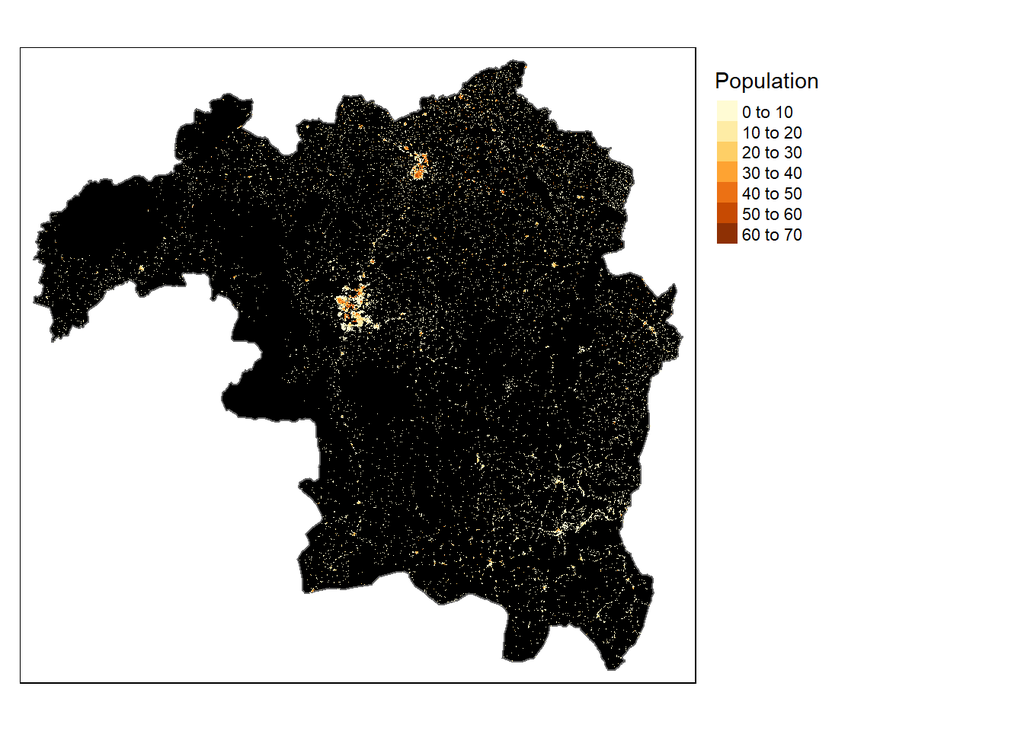

```r
tm_shape(state)+
  tm_borders()+
  tm_fill(col="black")+
  tm_shape(r)+
  tm_raster(title="Population")+
  tm_legend(legend.position=c("left","top"),legend.outside=TRUE)
```

# Coverage Calculations

We are interested in finding out the health facility coverage, to identify populations that may be underserved. We will use voronoi polygons which provide an estimation of coverage, where for each health facility there will be a corresponding region that consists of area closer to that facility than any other.

Create a set of voronoi polygons from the point locations. We can use the `voronoi` function from the package **dismo** to calculate these:

```r
v <- voronoi(points)
```

Again, we will visualise these below:

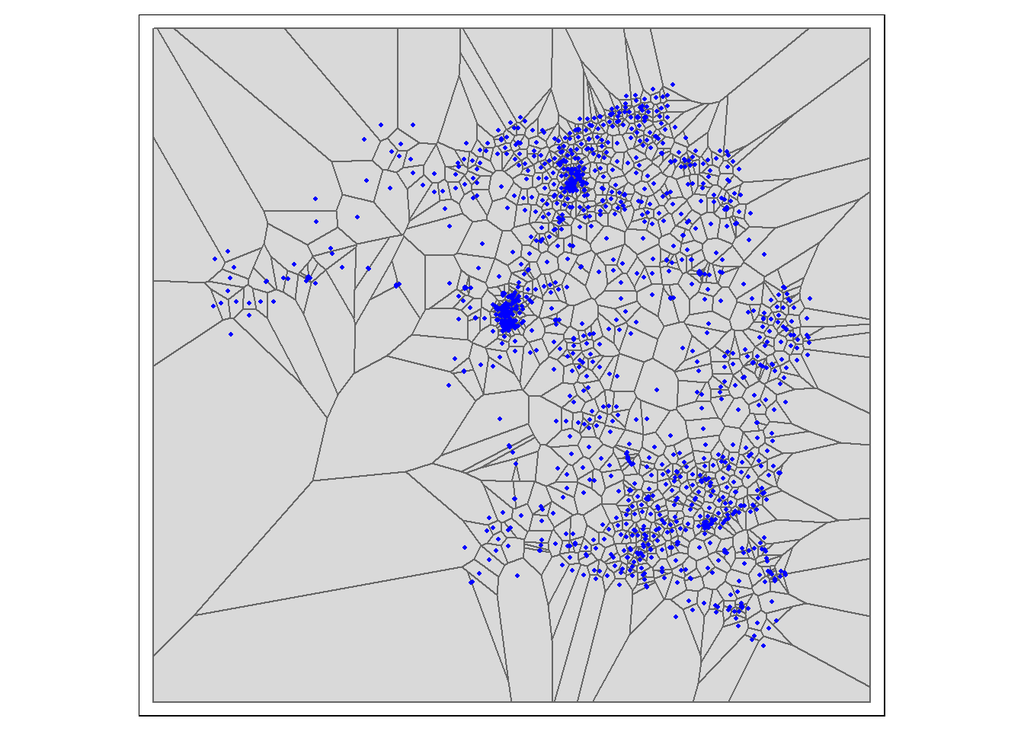

```r
tm_shape(v)+
 tm_borders()+
 tm_fill()+
tm_shape(points)+
 tm_dots(size=0.05,col="blue")
```

This shows an estimation of health facility coverage. Based on area, you can start to identify places that could benefit from new facilities. However, we first need to take the population estimates into account to find out how many people are being covered. Let’s compare population density to health facility density.

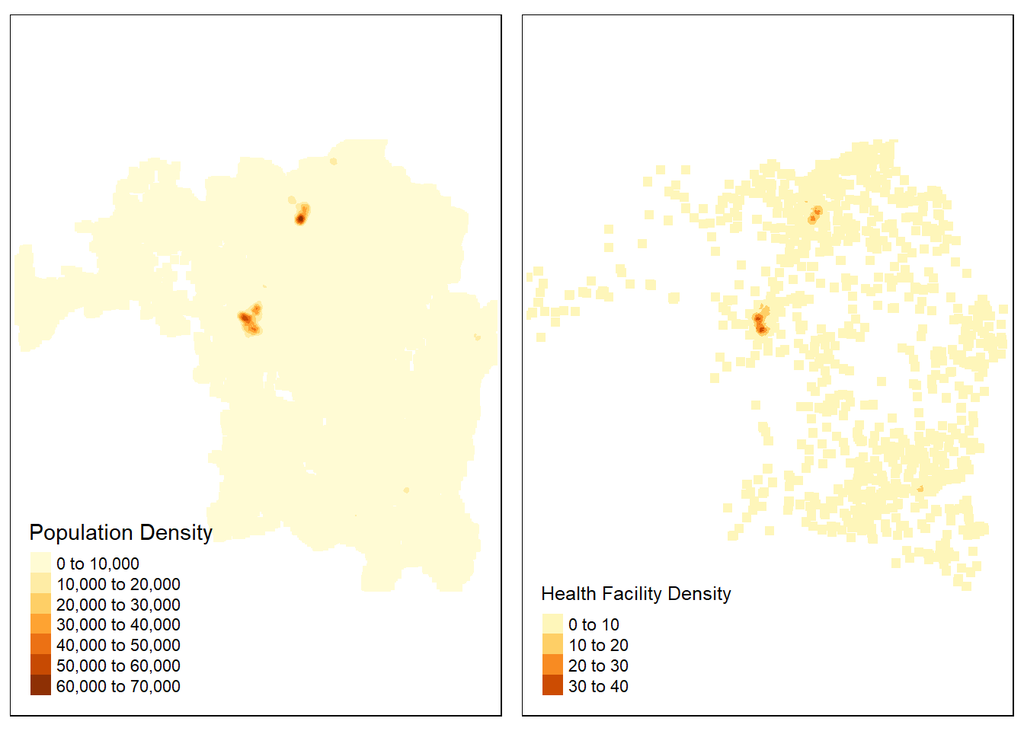

```r
a <- focalWeight(r, 0.025, "circle")
a[a > 0] <- 1
#p_dens <- focal(r, w = a, fun = sum, na.rm = TRUE)

#rast <- rasterize(points, r, field = 1)
#hf_dens <- focal(rast, w = a, fun = sum, na.rm = TRUE)

p_dens<-readRDS("p_dens")
hf_dens<-readRDS("hf_dens")

t1<-tm_shape(p_dens)+
    tm_raster(title="Population Density")+
    tm_legend(legend.position=c("left","bottom"))

t2<-tm_shape(hf_dens)+
    tm_raster(title="Health Facility Density")+
    tm_legend(legend.position=c("left","bottom"))

maps <- tmap_mode("plot")
tmap_arrange(t1,t2, widths = c(.5, .5))
```

```r
tmap_mode(maps)
```

# Identifying Relationships

We are going to look at the relationship between the facility density and population density. We can also use this to derive targets of the number of people per health facility.

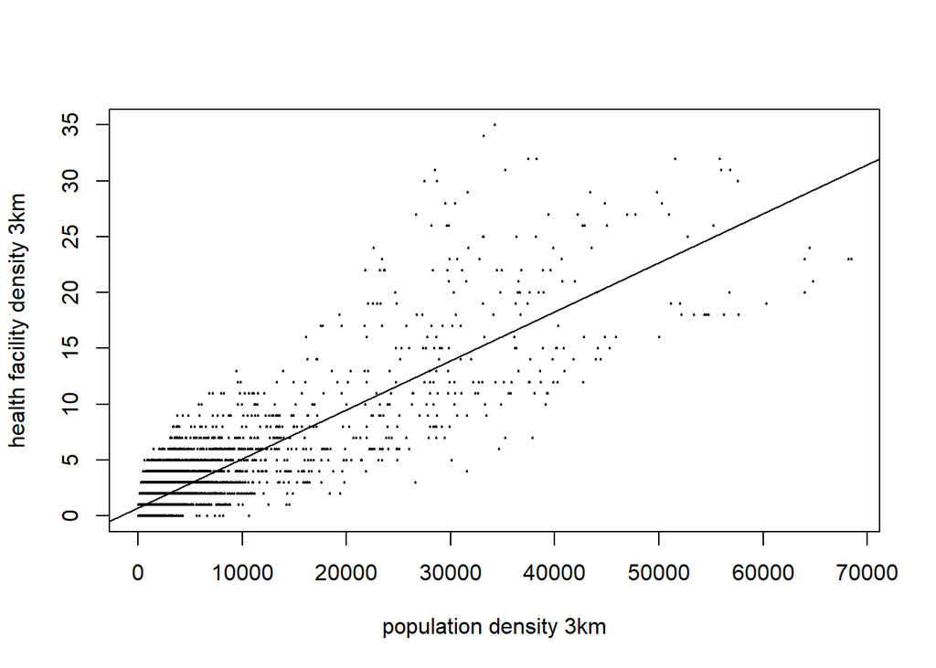

```r
plot(p_dens, hf_dens, xlab = "population density 3km", ylab = "health facility density 3km")
abline(lm(values(hf_dens) ~ values(p_dens)))
```

We could use a target of 5000 people per health facility to look at areas where health facilities are going to be serving too many people.Using zonal statistics, we need to calculate the number of people in each voronoi polyon.

```r
#z.stat <- zonal.stats(v, r, stat = sum, trace = FALSE, plot = FALSE)

#z.stat<-readRDS("z.stat")
#z <- data.frame(ID = v$name, sum = z.stat)
#head(z, nrow = 3)

z<-readRDS("z")

v@data <- data.frame(v@data, z[match(v@data[, "name"], z[, "ID"]), ])
```

Here, we are subsetting the data to only include those voronois above the ‘target’ that can be seen in red. These would be recommended for further intervention, such as the expansion of existing health facilities or placement of new facilities.

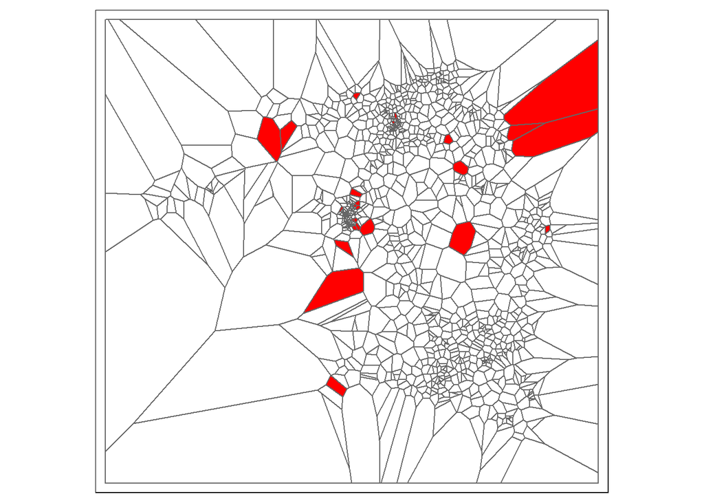

```r
sub <- subset(v, sum > 5000)

tm_shape(v)+
 tm_borders()+
 tm_fill(col="white")+
  tm_shape(sub)+
  tm_borders()+
  tm_fill(col="red")
```